# Exploratory Analysis Zillow

### Welcome and good luck to you all at Zillow’s Home Value prediction!

#### with a price pool of 1.2 Million Dollar

Here is a first exploratory analysis of the competition dataset. We are provided with a list of real estate properties in three counties (Los Angeles, Orange and Ventura, California) data in 2016.

Zillow provides a “Zestimate”, which is an estimated property value.

Our task in this competition is to predict the the difference between the actual price and the estimate of the price (Zestimate). So, in fact we are predicting, where Zillow’s Zestimate will be good, and where it will be bad.

So, far so good. However, we don’t have to predict a single value, but instead for 6 different time points (from October 2016 to December 2017) (see sample submission)

The dataset consists of information about 2.9 million properties and is grouped into 2 files:

- properties_2016.csv (containing information about the properties themselves)
- train_2016.csv (containing information about the transcations)

Let’s look at the dataset:

### Read in the data

```r
library(data.table)
library(dplyr)
library(ggplot2)
library(stringr)
library(DT)
library(tidyr)
library(corrplot)
library(leaflet)
library(lubridate)

properties <- fread('../input/properties_2016.csv')
transactions <- fread('../input/train_2016.csv')
sample_submission <- fread('../input/sample_submission.csv')
```

Lets first have a look at these files:

### Peek at the dataset

#### Properties

There is a total of 58 features per property. You can scroll the x-axis to see all features.

|  | parcelid | airconditioningtypeid | architecturalstyletypeid | basementsqft | bathroomcnt | bedroomcnt | buildingclasstypeid | buildingqualitytypeid | calculatedbathnbr | decktypeid | finishedfloor1squarefeet | calculatedfinishedsquarefeet | finishedsquarefeet12 | finishedsquarefeet13 | finishedsquarefeet15 | finishedsquarefeet50 | finishedsquarefeet6 | fips | fireplacecnt | fullbathcnt | garagecarcnt | garagetotalsqft | hashottuborspa | heatingorsystemtypeid | latitude | longitude | lotsizesquarefeet | poolcnt | poolsizesum | … |
| --- | --- | --- | --- | --- | --- | --- | --- | --- | --- | --- | --- | --- | --- | --- | --- | --- | --- | --- | --- | --- | --- | --- | --- | --- | --- | --- | --- | --- | --- | --- |
| 1 | 10754147 |  |  |  | 0 | 0 |  |  |  |  |  |  |  |  |  |  |  | 6037 |  |  |  |  |  |  | 34144442 | -118654084 | 85768 |  |  | … |
| 2 | 10759547 |  |  |  | 0 | 0 |  |  |  |  |  |  |  |  |  |  |  | 6037 |  |  |  |  |  |  | 34140430 | -118625364 | 4083 |  |  | … |
| 3 | 10843547 |  |  |  | 0 | 0 |  |  |  |  |  | 73026 |  |  | 73026 |  |  | 6037 |  |  |  |  |  |  | 33989359 | -118394633 | 63085 |  |  | … |
| 4 | 10859147 |  |  |  | 0 | 0 | 3 | 7 |  |  |  | 5068 |  |  | 5068 |  |  | 6037 |  |  |  |  |  |  | 34148863 | -118437206 | 7521 |  |  | … |
| 5 | 10879947 |  |  |  | 0 | 0 | 4 |  |  |  |  | 1776 |  |  | 1776 |  |  | 6037 |  |  |  |  |  |  | 34194168 | -118385816 | 8512 |  |  | … |
| 6 | 10898347 |  |  |  | 0 | 0 | 4 | 7 |  |  |  | 2400 |  |  | 2400 |  |  | 6037 |  |  |  |  |  |  | 34171873 | -118380906 | 2500 |  |  | … |
| 7 | 10933547 |  |  |  | 0 | 0 |  |  |  |  |  |  |  |  |  |  |  | 6037 |  |  |  |  |  |  | 34131929 | -118351474 |  |  |  | … |
| 8 | 10940747 |  |  |  | 0 | 0 |  |  |  |  |  | 3611 |  |  | 3611 |  |  | 6037 |  |  |  |  |  |  | 34171345 | -118314900 | 5333 |  |  | … |
| 9 | 10954547 |  |  |  | 0 | 0 |  |  |  |  |  |  |  |  |  |  |  | 6037 |  |  |  |  |  |  | 34218210 | -118331311 | 145865 |  |  | … |
| 10 | 10976347 |  |  |  | 0 | 0 | 3 | 7 |  |  |  | 3754 |  |  | 3754 |  |  | 6037 |  |  |  |  |  |  | 34289776 | -118432085 | 7494 |  |  | … |

[output cut: 90 more lines]

#### Transactions

|  | parcelid | logerror | transactiondate |
| --- | --- | --- | --- |
| 1 | 11016594 | 0.0276 | 2016-01-01 |
| 2 | 14366692 | -0.1684 | 2016-01-01 |
| 3 | 12098116 | -0.004 | 2016-01-01 |
| 4 | 12643413 | 0.0218 | 2016-01-02 |
| 5 | 14432541 | -0.005 | 2016-01-02 |
| 6 | 11509835 | -0.2705 | 2016-01-02 |
| 7 | 12286022 | 0.044 | 2016-01-02 |
| 8 | 17177301 | 0.1638 | 2016-01-02 |
| 9 | 14739064 | -0.003 | 2016-01-02 |
| 10 | 14677559 | 0.0843 | 2016-01-03 |

[output cut: 90 more lines]

#### Sample Submission

|  | V1 | V2 | V3 | V4 | V5 | V6 | V7 |
| --- | --- | --- | --- | --- | --- | --- | --- |
| 1 | ParcelId | 201610 | 201611 | 201612 | 201710 | 201711 | 201712 |
| 2 | 10754147 | 0 | 0 | 0 | 0 | 0 | 0 |
| 3 | 10759547 | 0 | 0 | 0 | 0 | 0 | 0 |
| 4 | 10843547 | 0 | 0 | 0 | 0 | 0 | 0 |
| 5 | 10859147 | 0 | 0 | 0 | 0 | 0 | 0 |
| 6 | 10879947 | 0 | 0 | 0 | 0 | 0 | 0 |
| 7 | 10898347 | 0 | 0 | 0 | 0 | 0 | 0 |
| 8 | 10933547 | 0 | 0 | 0 | 0 | 0 | 0 |
| 9 | 10940747 | 0 | 0 | 0 | 0 | 0 | 0 |
| 10 | 10954547 | 0 | 0 | 0 | 0 | 0 | 0 |

### Renaming the features

The feature names are (lets face it) not really interpretable well. How should you now what “finishedsquarefeet15” is for example. So, I am going to rename them here. This will make working with the dataset a lot easier (more consistency, and shorter names):

```r
properties <- properties %>% rename(
  id_parcel = parcelid,
  build_year = yearbuilt,
  area_basement = basementsqft,
  area_patio = yardbuildingsqft17,
  area_shed = yardbuildingsqft26,
  area_pool = poolsizesum,
  area_lot = lotsizesquarefeet,
  area_garage = garagetotalsqft,
  area_firstfloor_finished = finishedfloor1squarefeet,
  area_total_calc = calculatedfinishedsquarefeet,
  area_base = finishedsquarefeet6,
  area_live_finished = finishedsquarefeet12,
  area_liveperi_finished = finishedsquarefeet13,
  area_total_finished = finishedsquarefeet15,
  area_unknown = finishedsquarefeet50,
  num_unit = unitcnt,
  num_story = numberofstories,
  num_room = roomcnt,
  num_bathroom = bathroomcnt,
  num_bedroom = bedroomcnt,
  num_bathroom_calc = calculatedbathnbr,
  num_bath = fullbathcnt,
  num_75_bath = threequarterbathnbr,
  num_fireplace = fireplacecnt,
  num_pool = poolcnt,
  num_garage = garagecarcnt,
  region_county = regionidcounty,
  region_city = regionidcity,
  region_zip = regionidzip,
  region_neighbor = regionidneighborhood,
  tax_total = taxvaluedollarcnt,
  tax_building = structuretaxvaluedollarcnt,
  tax_land = landtaxvaluedollarcnt,
  tax_property = taxamount,
  tax_year = assessmentyear,
  tax_delinquency = taxdelinquencyflag,
  tax_delinquency_year = taxdelinquencyyear,
  flag_fireplace = fireplaceflag,
  flag_tub = hashottuborspa,
  quality = buildingqualitytypeid,
  framing = buildingclasstypeid,
  material = typeconstructiontypeid,
  deck = decktypeid,
  story = storytypeid,
  heating = heatingorsystemtypeid,
  aircon = airconditioningtypeid,
  architectural_style= architecturalstyletypeid
)
transactions <- transactions %>% rename(
  id_parcel = parcelid,
  date = transactiondate
)

properties <- properties %>%
  mutate(tax_delinquency = ifelse(tax_delinquency=="Y",1,0),
         flag_fireplace = ifelse(flag_fireplace=="Y",1,0),
         flag_tub = ifelse(flag_tub=="Y",1,0))
```

### Peek at the renamed dataset

#### Properties

Much better :-). You can scroll the x-axis to see all features.

|  | id_parcel | build_year | area_basement | area_firstfloor_finished | area_total_calc | area_live_finished | area_liveperi_finished | area_total_finished | area_unknown | area_base | area_garage | area_lot | area_pool | area_patio | area_shed | num_bathroom | num_bedroom | num_bathroom_calc | num_fireplace | num_bath | num_garage | num_pool | num_room | num_75_bath | num_unit | num_story | flag_tub | flag_fireplace | region_city | … |
| --- | --- | --- | --- | --- | --- | --- | --- | --- | --- | --- | --- | --- | --- | --- | --- | --- | --- | --- | --- | --- | --- | --- | --- | --- | --- | --- | --- | --- | --- | --- |
| 1 | 10754147 |  |  |  |  |  |  |  |  |  |  | 85768 |  |  |  | 0 | 0 |  |  |  |  |  | 0 |  |  |  | 0 | 0 | 37688 | … |
| 2 | 10759547 |  |  |  |  |  |  |  |  |  |  | 4083 |  |  |  | 0 | 0 |  |  |  |  |  | 0 |  |  |  | 0 | 0 | 37688 | … |
| 3 | 10843547 |  |  |  | 73026 |  |  | 73026 |  |  |  | 63085 |  |  |  | 0 | 0 |  |  |  |  |  | 0 |  | 2 |  | 0 | 0 | 51617 | … |
| 4 | 10859147 | 1948 |  |  | 5068 |  |  | 5068 |  |  |  | 7521 |  |  |  | 0 | 0 |  |  |  |  |  | 0 |  |  | 1 | 0 | 0 | 12447 | … |
| 5 | 10879947 | 1947 |  |  | 1776 |  |  | 1776 |  |  |  | 8512 |  |  |  | 0 | 0 |  |  |  |  |  | 0 |  | 1 |  | 0 | 0 | 12447 | … |
| 6 | 10898347 | 1943 |  |  | 2400 |  |  | 2400 |  |  |  | 2500 |  |  |  | 0 | 0 |  |  |  |  |  | 0 |  |  | 1 | 0 | 0 | 12447 | … |
| 7 | 10933547 |  |  |  |  |  |  |  |  |  |  |  |  |  |  | 0 | 0 |  |  |  |  |  | 0 |  |  |  | 0 | 0 | 12447 | … |
| 8 | 10940747 | 1946 |  |  | 3611 |  |  | 3611 |  |  |  | 5333 |  |  |  | 0 | 0 |  |  |  |  |  | 0 |  |  | 1 | 0 | 0 | 396054 | … |
| 9 | 10954547 |  |  |  |  |  |  |  |  |  |  | 145865 |  |  |  | 0 | 0 |  |  |  |  |  | 0 |  |  |  | 0 | 0 | 396054 | … |
| 10 | 10976347 | 1978 |  |  | 3754 |  |  | 3754 |  |  |  | 7494 |  |  |  | 0 | 0 |  |  |  |  |  | 0 |  |  | 1 | 0 | 0 | 47547 | … |

[output cut: 90 more lines]

#### Transactions

|  | id_parcel | logerror | date |
| --- | --- | --- | --- |
| 1 | 11016594 | 0.0276 | 2016-01-01 |
| 2 | 14366692 | -0.1684 | 2016-01-01 |
| 3 | 12098116 | -0.004 | 2016-01-01 |
| 4 | 12643413 | 0.0218 | 2016-01-02 |
| 5 | 14432541 | -0.005 | 2016-01-02 |
| 6 | 11509835 | -0.2705 | 2016-01-02 |
| 7 | 12286022 | 0.044 | 2016-01-02 |
| 8 | 17177301 | 0.1638 | 2016-01-02 |
| 9 | 14739064 | -0.003 | 2016-01-02 |
| 10 | 14677559 | 0.0843 | 2016-01-03 |

[output cut: 90 more lines]

### Transaction Dates

This is a little bit confusing at first glance: There are three different time slots for transactions. So I made a figure:

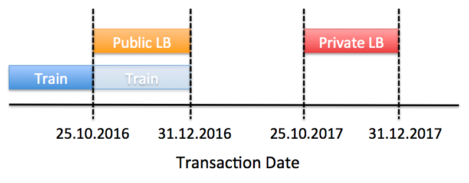

#### Distribution of transaction dates

As shown in the figure above, there are only some of the transactions after 25.10 in the train set, because the rest is in the test set (for the public LB).

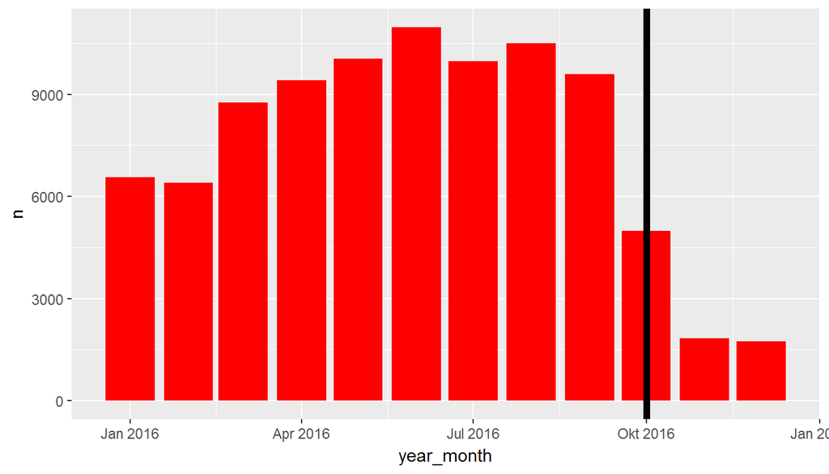

```r
tmp <- transactions %>% mutate(year_month = make_date(year=year(date),month=month(date)))
tmp %>%
  group_by(year_month) %>% count() %>%
  ggplot(aes(x=year_month,y=n)) +
  geom_bar(stat="identity", fill="red")+
  geom_vline(aes(xintercept=as.numeric(as.Date("2016-10-01"))),size=2)
```

### Outcome

To get a feel for the data let’s first have a look at the distribution of our outcome (logerror), i.e. the difference in log(Zestimate)-log(Saleprice)

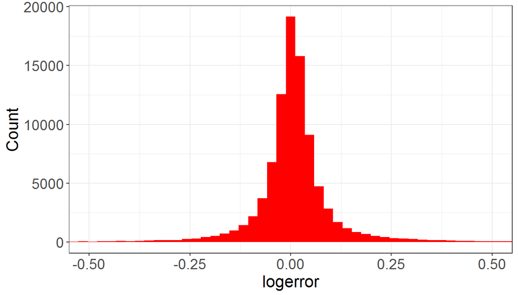

```r
transactions %>%
  ggplot(aes(x=logerror)) +
  geom_histogram(bins=400, fill="red")+
  theme_bw()+theme(axis.title = element_text(size=16),axis.text = element_text(size=14))+
  ylab("Count")+coord_cartesian(x=c(-0.5,0.5))
```

### More thoughts about the outcome

In fact there are two outcomes you can look at:

- logerror: log(Zestimate) - log(Saleprice). So a positive logerror means Zestimate is overestimating the Saleprice, a negative logerror means that Zestimate is underestimating Saleprice.
- absolute logerror: a small value means that log(Zestimate) is close to log(Saleprice). So, Zestimate predictions are close to Saleprice.

Any association with logerror would indicate that a feature would be associated with over- or understimating the sale price. Any association of a feature with absolute logerror would indicate that the feature is associated with a better or worse Zestimate.

### Absolute logerror

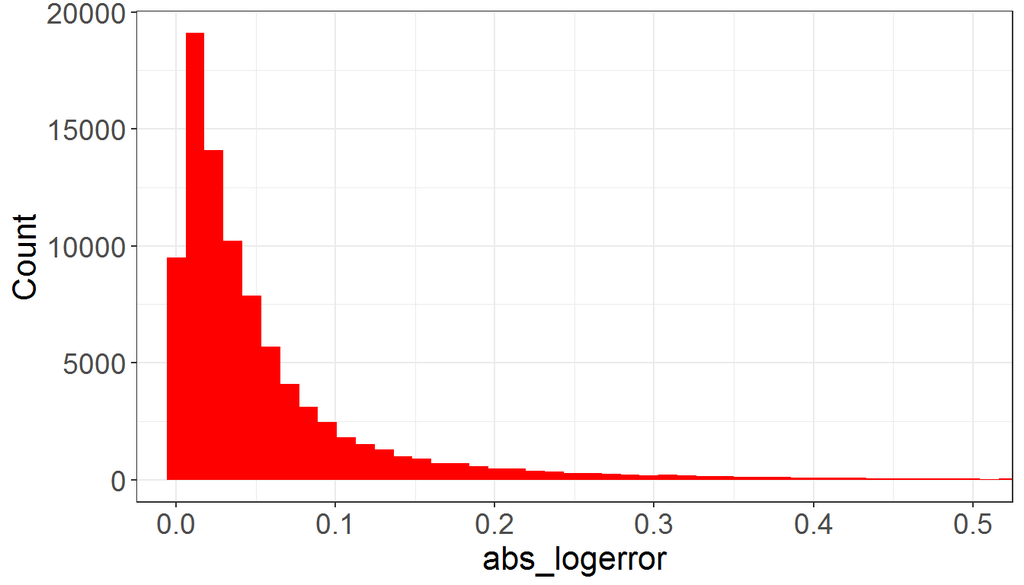

```r
transactions <- transactions %>% mutate(abs_logerror = abs(logerror))
transactions %>%
  ggplot(aes(x=abs_logerror)) +
  geom_histogram(bins=400, fill="red")+
  theme_bw()+theme(axis.title = element_text(size=16),axis.text = element_text(size=14))+
  ylab("Count")+coord_cartesian(x=c(0,0.5))
```

### How does absolute log error change with time

There seems to be a light trend that Zestimates error decreases over time. Predictions are getting better. Zillow seems to have good data scientists :-).

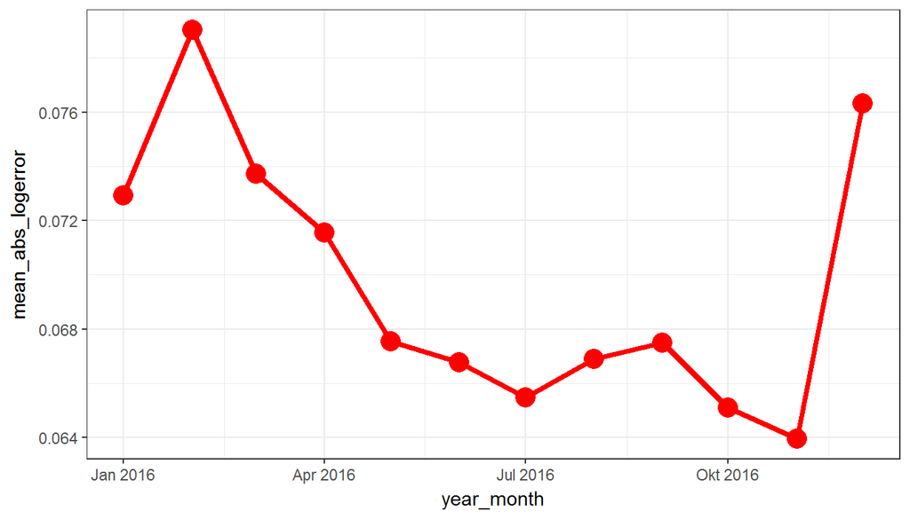

```r
transactions %>%
  mutate(year_month = make_date(year=year(date),month=month(date)) ) %>%
  group_by(year_month) %>% summarize(mean_abs_logerror = mean(abs_logerror)) %>%
  ggplot(aes(x=year_month,y=mean_abs_logerror)) +
  geom_line(size=1.5, color="red")+
  geom_point(size=5, color="red")+theme_bw()
```

### How does log error change with time

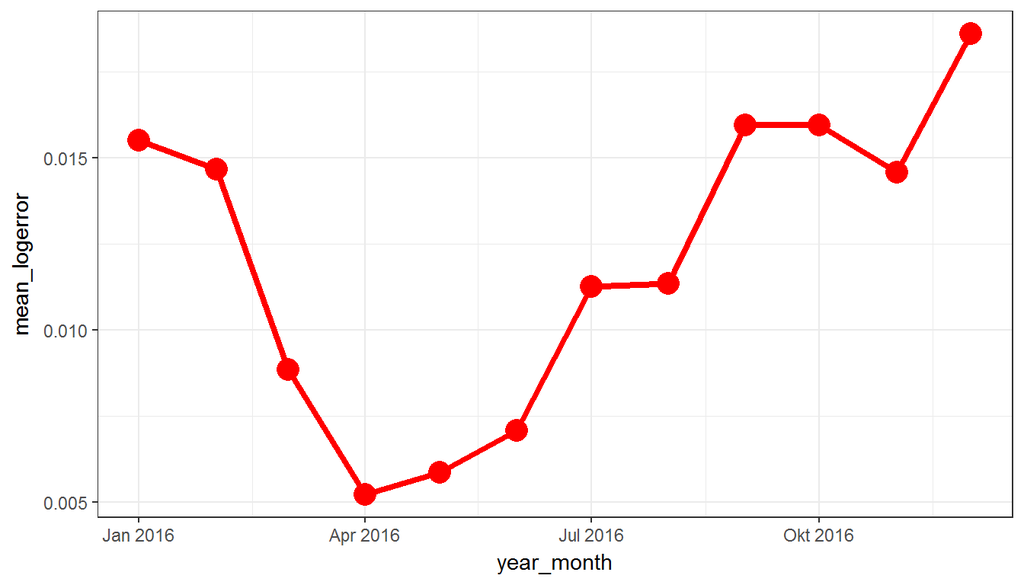

```r
transactions %>%
  mutate(year_month = make_date(year=year(date),month=month(date)) ) %>%
  group_by(year_month) %>% summarize(mean_logerror = mean(logerror)) %>%
  ggplot(aes(x=year_month,y=mean_logerror)) +
  geom_line(size=1.5, color="red")+geom_point(size=5, color="red")+theme_bw()
```

### Missing values

We have seen many missing values in the data peeking. How many missing values are there for each feature? In fact, some features are missing nearly completely. So, we probably have to work more with the others.

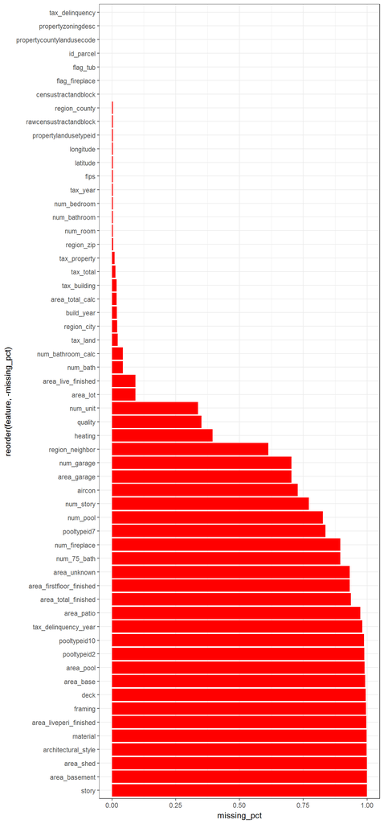

```r
missing_values <- properties %>% summarize_each(funs(sum(is.na(.))/n()))

missing_values <- gather(missing_values, key="feature", value="missing_pct")
missing_values %>%
  ggplot(aes(x=reorder(feature,-missing_pct),y=missing_pct)) +
  geom_bar(stat="identity",fill="red")+
  coord_flip()+theme_bw()
```

```r
good_features <- filter(missing_values, missing_pct<0.75)
```

### Correlation with absolute logerror

num_ features:

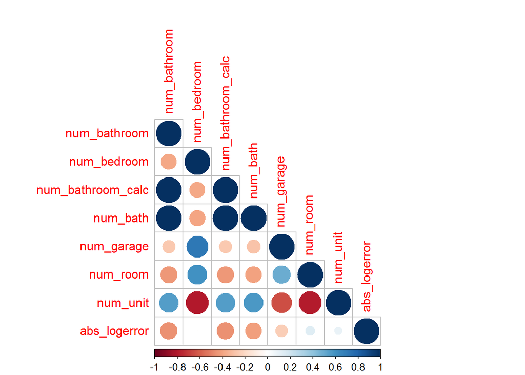

```r
vars <- good_features$feature[str_detect(good_features$feature,'num_')]

cor_tmp <- transactions %>% left_join(properties, by="id_parcel")
tmp <- cor_tmp %>% select(one_of(c(vars,"abs_logerror")))

corrplot(cor(tmp, use="complete.obs"),type="lower")
```

### Correlation with absolute logerror

area_ features

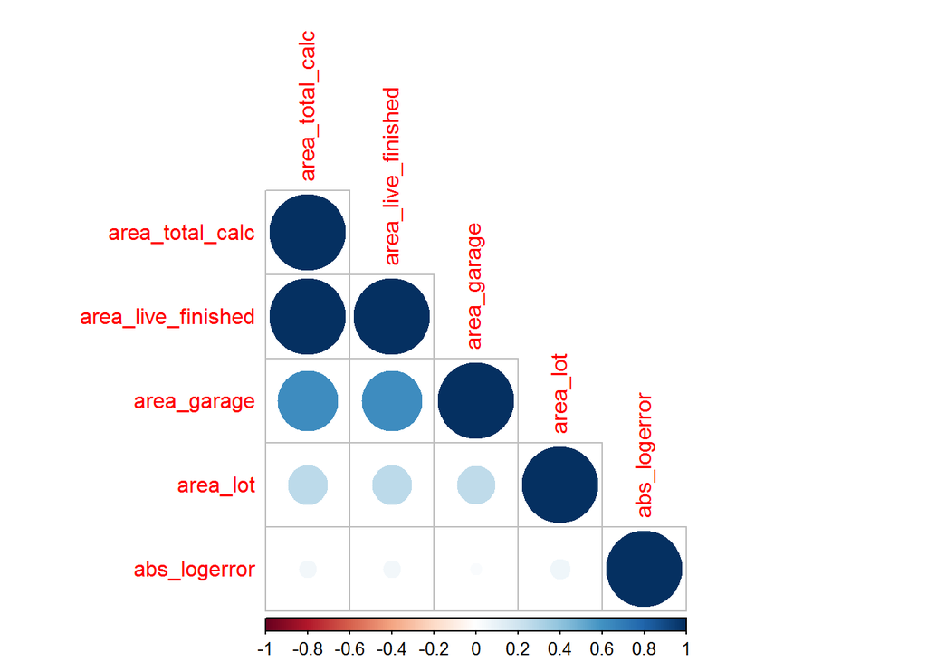

```r
vars <- good_features$feature[str_detect(good_features$feature,'area_')]

tmp <- cor_tmp %>% select(one_of(c(vars,"abs_logerror")))

corrplot(cor(tmp, use="complete.obs"), type="lower")
```

### Correlation with absolute logerror

tax_ features

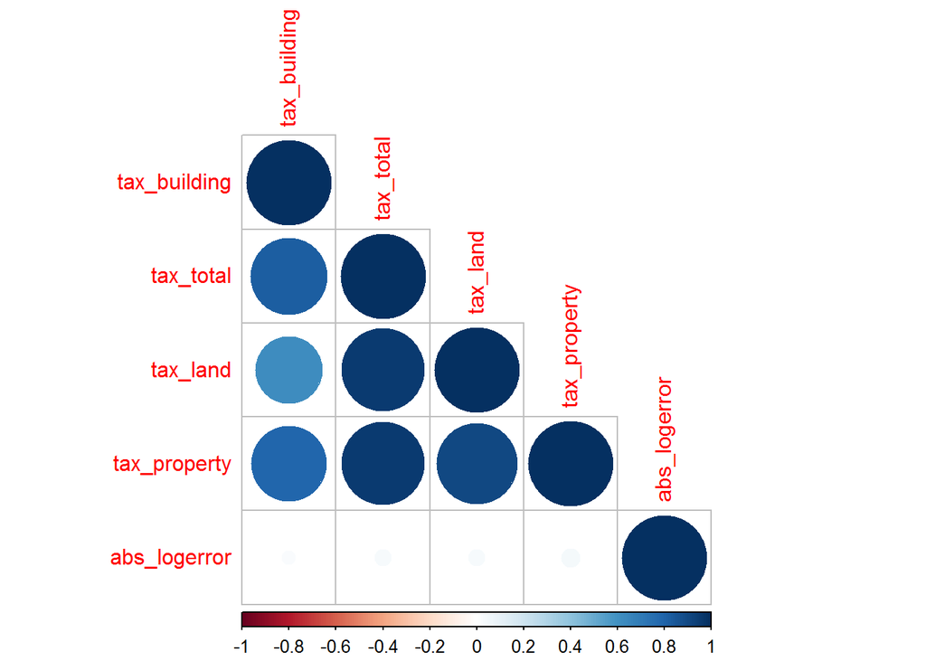

```r
vars <- setdiff(good_features$feature[str_detect(good_features$feature,'tax_')],c("tax_delinquency","tax_year"))

tmp <- cor_tmp %>% select(one_of(c(vars,"abs_logerror")))

corrplot(cor(tmp, use="complete.obs"), type="lower")
```

### Correlation with logerror

num_ features: There seems to be small negative correlations between the num features and logerror.

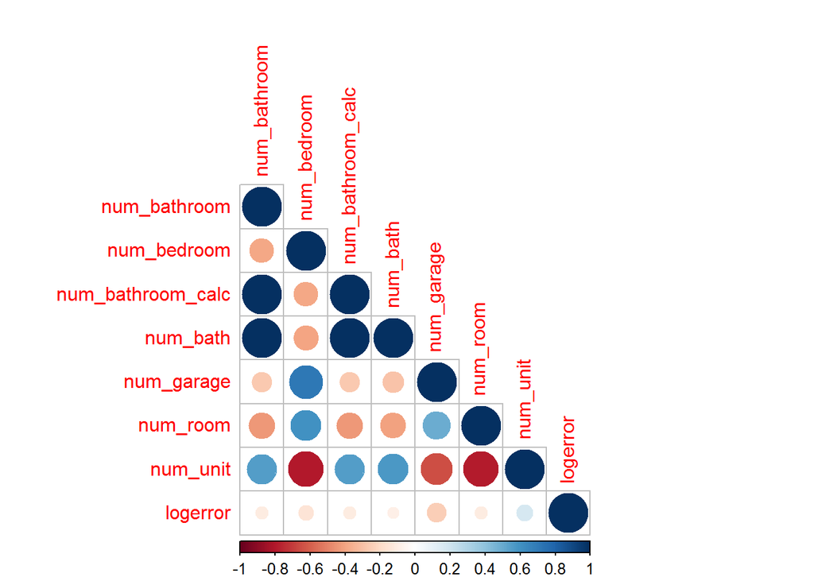

```r
vars <- good_features$feature[str_detect(good_features$feature,'num_')]

cor_tmp <- transactions %>% left_join(properties, by="id_parcel")
tmp <- cor_tmp %>% select(one_of(c(vars,"logerror")))

corrplot(cor(tmp, use="complete.obs"),type="lower")
```

### Correlation with logerror

area_ features

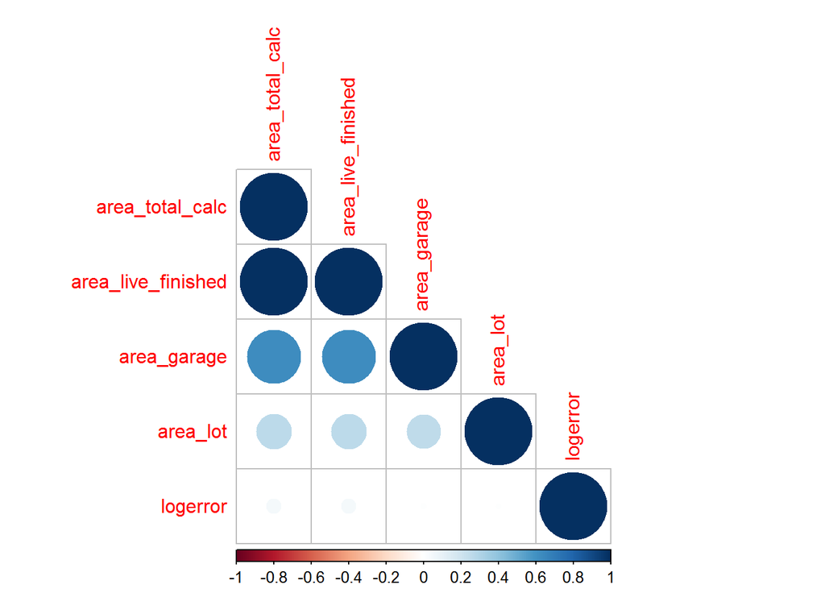

```r
vars <- good_features$feature[str_detect(good_features$feature,'area_')]

tmp <- cor_tmp %>%  select(one_of(c(vars,"logerror")))

corrplot(cor(tmp, use="complete.obs"), type="lower")
```

### Correlation with logerror

tax_ features

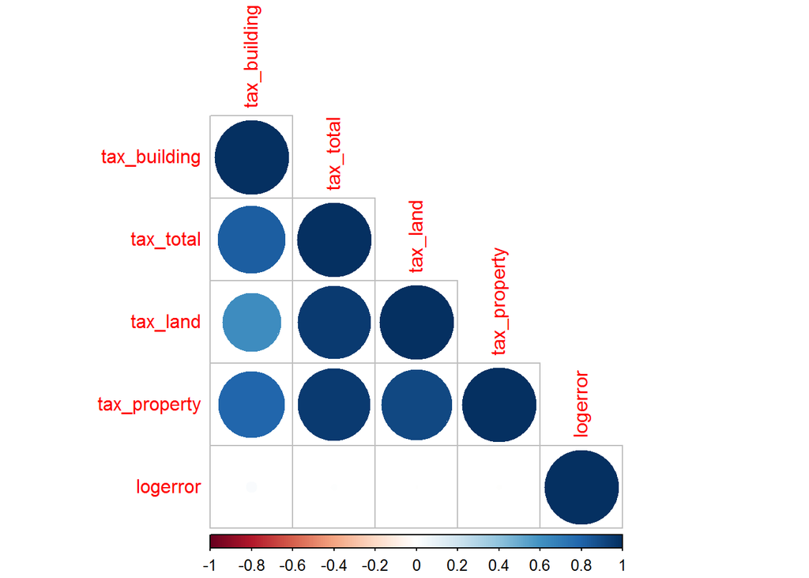

```r
vars <- setdiff(good_features$feature[str_detect(good_features$feature,'tax_')],c("tax_delinquency","tax_year"))

tmp <- cor_tmp %>%  select(one_of(c(vars,"logerror")))

corrplot(cor(tmp, use="complete.obs"), type="lower")
```

### How does the absolute logerror change with build_year?

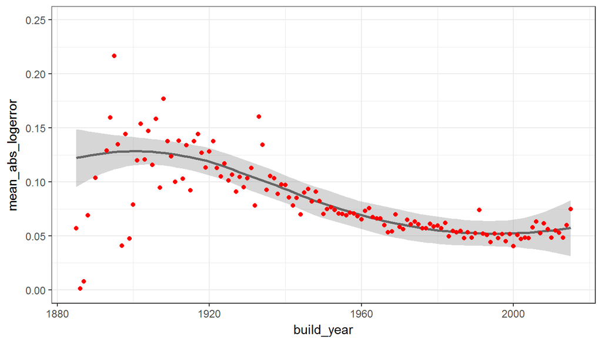

```r
cor_tmp %>%
  group_by(build_year) %>%
  summarize(mean_abs_logerror = mean(abs(logerror))) %>%
  ggplot(aes(x=build_year,y=mean_abs_logerror))+
  geom_smooth(color="grey40")+
  geom_point(color="red")+coord_cartesian(ylim=c(0,0.25))+theme_bw()
```

### How does the logerror change with build_year?

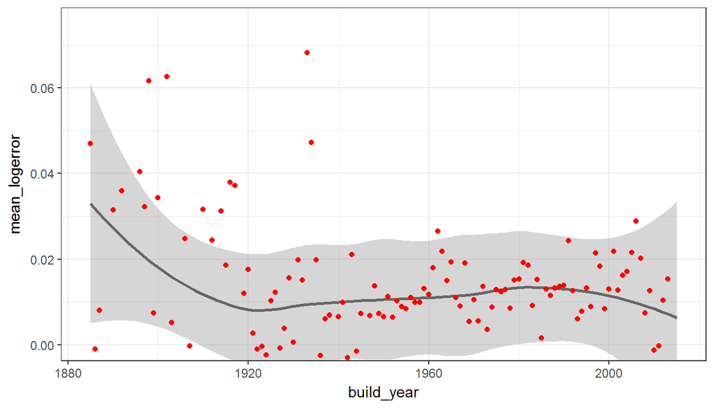

```r
cor_tmp %>%
  group_by(build_year) %>%
  summarize(mean_logerror = mean(logerror)) %>%
  ggplot(aes(x=build_year,y=mean_logerror))+
  geom_smooth(color="grey40")+
  geom_point(color="red")+coord_cartesian(ylim=c(0,0.075))+theme_bw()
```

### Where does Zestimate predict well?

To get a quick feel where zestimate predicts well, we can group our absolute logerror into different percentiles, e.g. the percentile with best predictions (top 10%), worst predictions (worst 10%) and typical predictions (50% around the median).

```r
transactions <- transactions %>% mutate(percentile = cut(abs_logerror,quantile(abs_logerror, probs=c(0, 0.1, 0.25, 0.75, 0.9, 1),names = FALSE),include.lowest = TRUE,labels=FALSE))

tmp1 <- transactions %>%
  filter(percentile == 1) %>%
  sample_n(5000) %>%
  left_join(properties, by="id_parcel")
tmp2 <- transactions %>%
  filter(percentile == 5) %>%
  sample_n(5000) %>%
  left_join(properties, by="id_parcel")
tmp3 <- transactions %>%
  filter(percentile == 3) %>%
  sample_n(5000) %>%
  left_join(properties, by="id_parcel")

tmp1 <- tmp1 %>% mutate(type="best_fit")
tmp2 <- tmp2 %>% mutate(type="worst_fit")
tmp3 <- tmp3 %>% mutate(type="typical_fit")


tmp <- bind_rows(tmp1,tmp2,tmp3)
tmp <- tmp %>% mutate(type = factor(type,levels = c("worst_fit", "typical_fit", "best_fit")))
```

If the distributions of features are largely overlapping for these three groups of transactions the feature most likely does not have a large effect on the goodness of estimation. Let’s see one example.

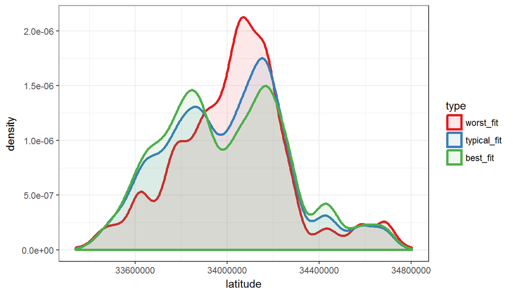

```r
col_pal <- "Set1"

tmp %>% ggplot(aes(x=latitude, fill=type, color=type)) + geom_density(alpha=0.1, size=1.2) + theme_bw()+scale_fill_brewer(palette=col_pal)+scale_color_brewer(palette=col_pal)
```

We can see that rows resulting in the worst predictions have a lower density for lower latitude values, but a higher density for intermediate latitudes (around 34000000).

We can examine this effect more closely and plot the absolute logerror as a function of latitude.

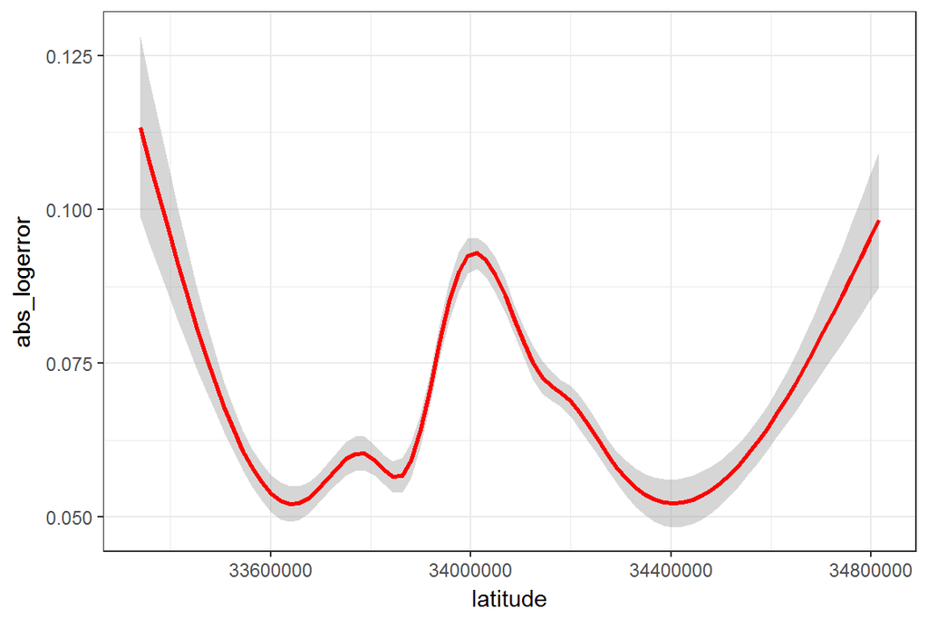

```r
tmptrans <- transactions %>%
  left_join(properties, by="id_parcel")

tmptrans %>%
  ggplot(aes(x=latitude,y=abs_logerror))+geom_smooth(color="red")+theme_bw()
```

Having seen the example, we can look at other features quickly, to see which are associated with absolute logerror.

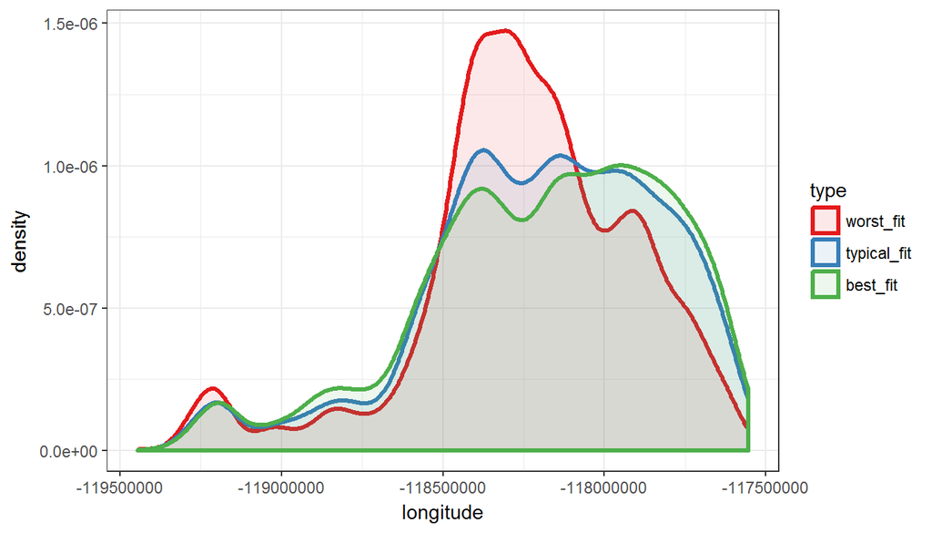

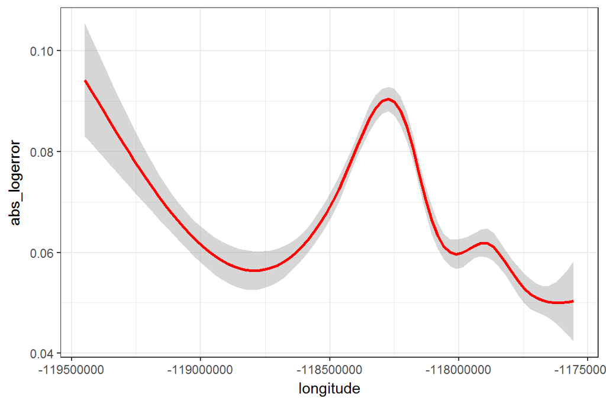

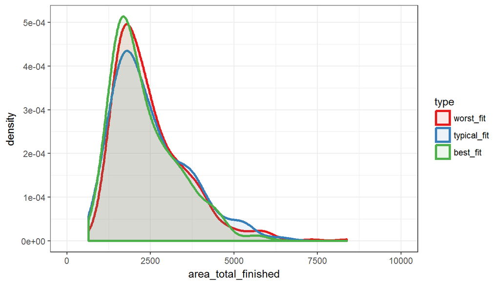

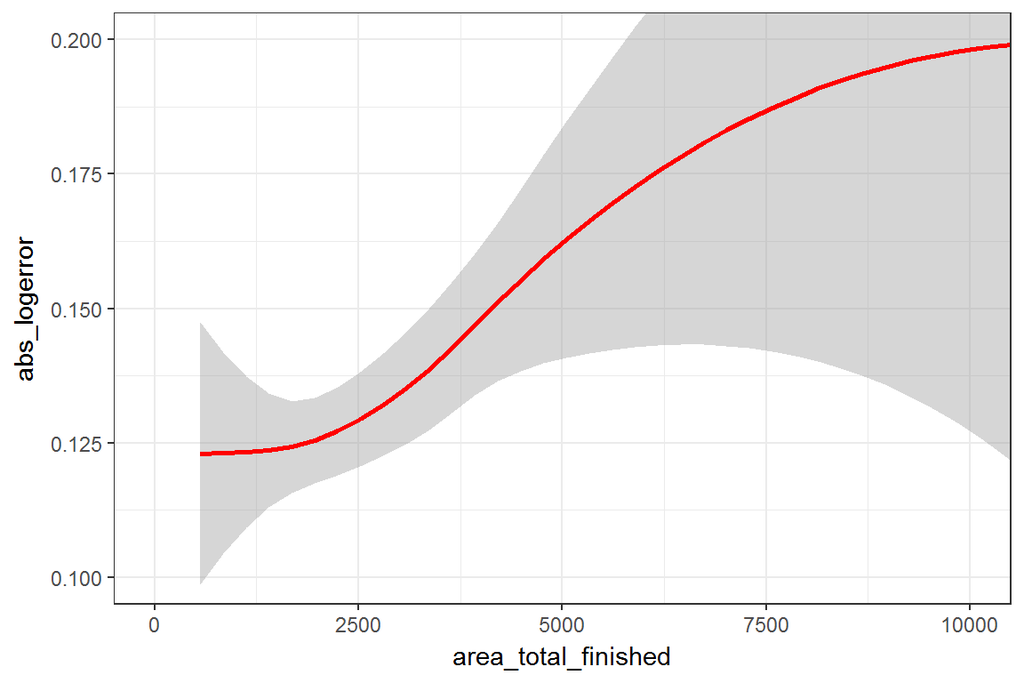

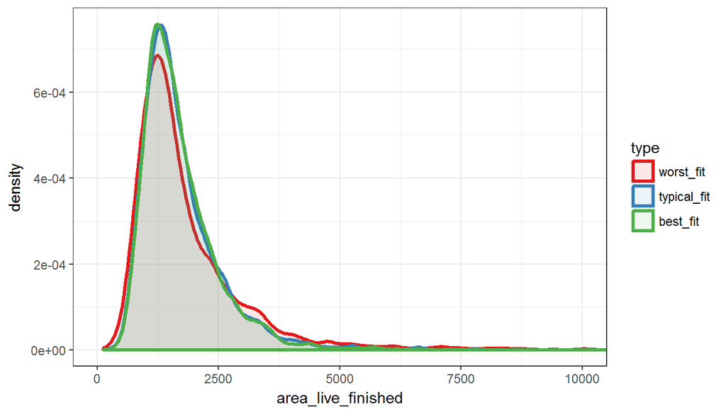

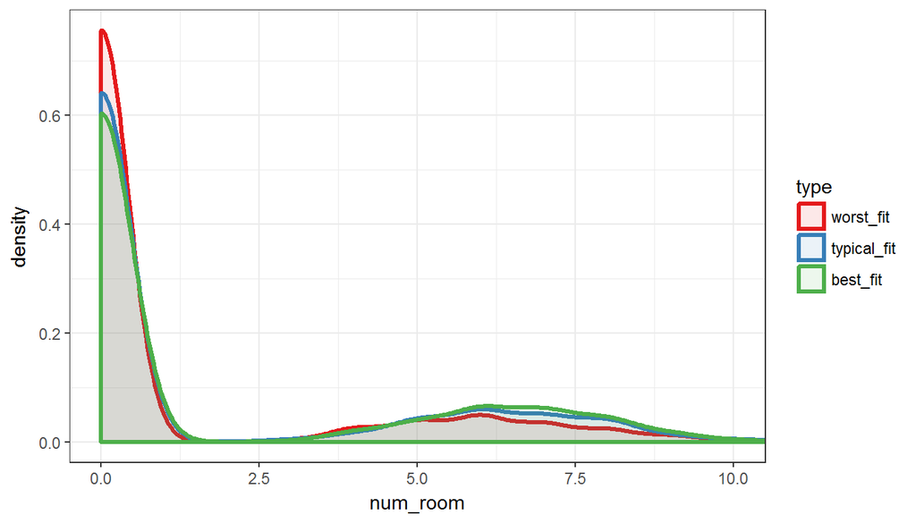

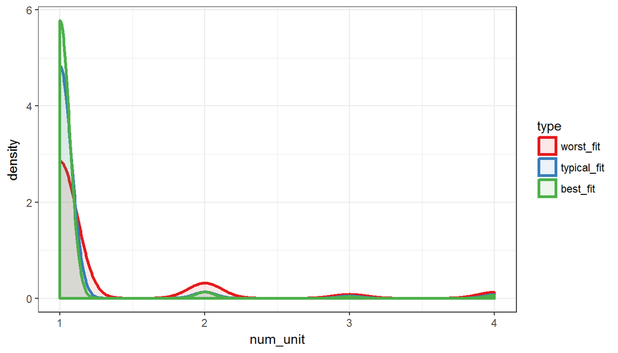

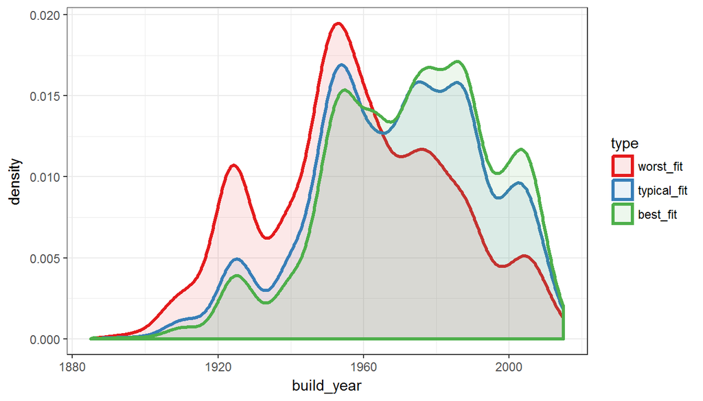

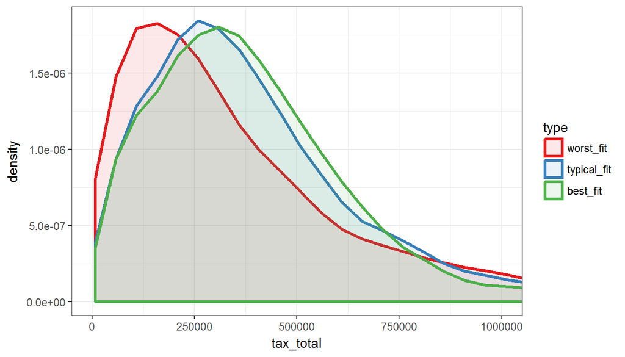

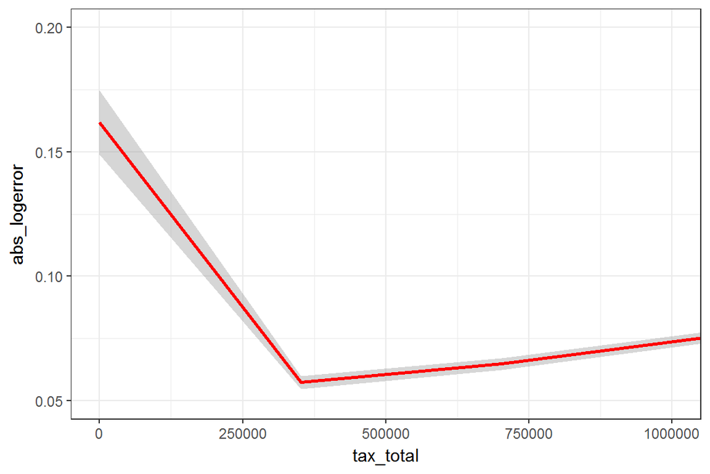

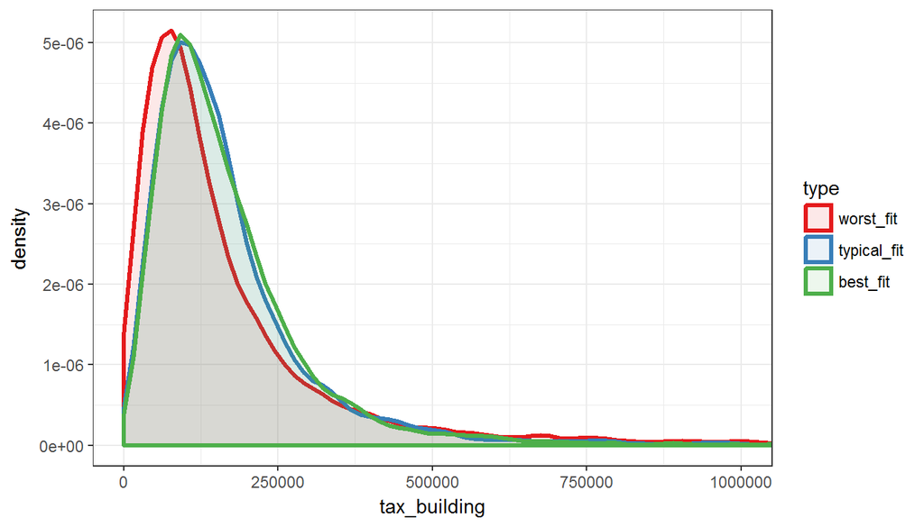

### Where are all those properties?

Show 2,000 of the properties on the map.

```r
lat <- range(properties$latitude/1e06,na.rm=T)
lon <- range(properties$longitude/1e06,na.rm=T)

tmp <- properties %>%
  sample_n(2000) %>%
  select(id_parcel,longitude,latitude) %>%
  mutate(lon=longitude/1e6,lat=latitude/1e6) %>%
  select(id_parcel,lat,lon) %>%
  left_join(transactions,by="id_parcel")

leaflet(tmp) %>%
  addTiles() %>%
  fitBounds(lon[1],lat[1],lon[2],lat[2]) %>%
  addCircleMarkers(stroke=FALSE)
```

[interactive chart not shown]

### Map absolute logerror

Show the absolute logerror on map. Red = higher.

```r
tmp <- transactions %>%
  sample_n(2000) %>%
  left_join(properties,by="id_parcel") %>%
  select(id_parcel,longitude,latitude, abs_logerror) %>%
  mutate(lon=longitude/1e6,lat=latitude/1e6) %>%
  select(id_parcel,lat,lon, abs_logerror)

qpal <- colorQuantile("YlOrRd", tmp$abs_logerror, n = 7)

leaflet(tmp) %>%
  addTiles() %>%
  fitBounds(lon[1],lat[1],lon[2],lat[2]) %>%
  addCircleMarkers(stroke=FALSE, color=~qpal(abs_logerror),fillOpacity = 1) %>%
  addLegend("bottomright", pal = qpal, values = ~abs_logerror,title = "Absolute logerror",opacity = 1)
```

[interactive chart not shown]

### What do these features mean?

I was really unsure about the meaning of the variables:

- ‘rawcensustractandblock’

A wikipedia search revealed:

Census tracts represent the smallest territorial unit for which population data are available in many countries.[3] In the United States, census tracts are subdivided into block groups and census blocks. In the U.S., census tracts are “designed to be relatively homogeneous units with respect to population characteristics, economic status, and living conditions” and “average about 4,000 inhabitants”.

Ok thats interesting. This opens up the possibility to incorporate external data from census into the analysis. So it’s worth exploring further:

```r
str(properties$rawcensustractandblock[1])
```

```
##  num 60378002
```

Looks like a number. However a closer look reveals its actually a number composed of two parts, separated by a dot.

```r
as.character(properties$rawcensustractandblock[1])
```

```
## [1] "60378002.041"
```

Ok, so far so good. So from what I read this number consisits of: FIPS Code (6037) - Tract Number (8002.04) - And block Number (1)

Let’s specifically add the tract number and block number information

```r
properties <- properties %>% mutate(census = as.character(rawcensustractandblock), tract_number = str_sub(census,5,11), tract_block = str_sub(census,12))
```

Let’s look at fips codes first:

You can look up some information [here](https://www.ffiec.gov/census/Default.aspx)

- 6037 Los Angeles
- 6059 Orange County
- 6111 Ventura County

Now, that you have the tract number you can get information such as tract income level, median family income, tract population, etc. **This might really be valueable information for the prediction**

For our example “6037 8002.04” lets look up some information:

https://www.ffiec.gov/census/report.aspx?year=2016&county=037&tract=8002.04&state=06&report=demographic

So I wish you some happy information gathering.

I am going to add more information later. So stay tuned.

And:

If the kernel helped you and you **upvote**, you make me happy :-)